# DS202W - Spring Term Summative

Author

Candidate Number - 48372

### Part 0: Preparation work: Loading Packages / Modules

```python
import pandas as pd
import numpy as np
import matplotlib.pyplot as plt
import re

from sklearn.feature_extraction.text import TfidfVectorizer, CountVectorizer
from sklearn.metrics.pairwise import cosine_similarity
from sklearn.decomposition import TruncatedSVD, LatentDirichletAllocation

from sklearn.cluster import KMeans
from sklearn.metrics import silhouette_score

import seaborn as sns
from langdetect import detect
```

### Part 0: Load raw datasets

```python
# Load Consumer Complaints Dataset. 'cc' stands for consumer complaints.
cc_df = pd.read_csv('./complaints_reduced/complaints_reduced.csv')

# Load EU Debates Dataset.
eu_df = pd.read_json('./eu_debates/train.jsonl', lines=True)
```

### Part 1 - Similarity: Consumer Complaints Database

#### Part 1-1: Creating subsample of Consumer Complaint Dataset

##### Sampling with **Simple Random Sampling (SRS)** : I will use **SRS** to take samples of cc_df (raw data) because the size of raw data is too big to work on. The biggest advantage is that SRS minimizes **selection bias**, because every record has an equal opportunity of being selected. Another advantage is that SRS is simpler and more straightforward than other sampling methods; One technical disadvantage of SRS is my machine needs to process the entire dataset at once, which might cause some memory issues. However, in contrast, other common sampling methods contain more serious issues I want to avoid:

##### For **systematic sampling**, it could **introduce biases to hidden patterns or underlying periodicity**. Because systematic sampling strictly selects samples with a specified interval, it is possible for patterns to be either over or under represented.

##### For **cluster and stratified sampling**, they require a prior understanding of the structure of the raw dataset to set strata and clusters. However, my data is not only complicated but also very big in size, which makes these 2 methods less feasible.

##### Code Explain: I have created a sample (sampled_cc_df) that contains 2% of raw data (cc_df). I specify sampling fraction, use seed to maintain reproducibility, and reset index order. After that, I observe the data structure, and use len(sampled_cc_df)/len(cc_df) to make sure the sample is indeed 2% of the population.

##### I made the choice **“2%”** after numerous tests. Initially, I tried 10%, 8%, or 5%, but these large sample sizes consistently resulted in a **MemoryError** in later procedures, regardless of whether I applied **dimensionality reduction (using svd)** or not.”

#### However, considering cc_df has 2,681,978 rows, even a 2% sample would still contain roughly 50,000 pieces of data, which is more than sufficient to observe meaningful similarity patterns.

```python
sample_fraction = 0.02
sampled_cc_df = cc_df.sample(frac=sample_fraction, random_state=12345)
sampled_cc_df = sampled_cc_df.reset_index(drop=True)           # reset index

print(len(sampled_cc_df)/len(cc_df))
sampled_cc_df.head(5)
```

```
0.020000164058019864
```

|  | Date received | Product | Sub-product | Issue | Sub-issue | Consumer complaint narrative | Company public response | Company | State | ZIP code | Tags | Consumer consent provided? | Submitted via | Date sent to company | Company response to consumer | Timely response? | Consumer disputed? | Complaint ID |
| --- | --- | --- | --- | --- | --- | --- | --- | --- | --- | --- | --- | --- | --- | --- | --- | --- | --- | --- |
| 0 | 2025-01-19 | Money transfer, virtual currency, or money ser... | Domestic (US) money transfer | Other transaction problem | NaN | I am writing to formally express my concerns r... | NaN | Early Warning Services, LLC | FL | 32818 | NaN | Consent provided | Web | 2025-01-19 | Closed with explanation | Yes | NaN | 11622643 |
| 1 | 2025-01-13 | Credit reporting or other personal consumer re... | Credit reporting | Problem with a company's investigation into an... | Investigation took more than 30 days | I have several complaints and in light of the ... | Company has responded to the consumer and the ... | TRANSUNION INTERMEDIATE HOLDINGS, INC. | GA | 30038 | NaN | Consent provided | Web | 2025-01-13 | Closed with explanation | Yes | NaN | 11485537 |
| 2 | 2018-07-28 | Credit reporting, credit repair services, or o... | Credit reporting | Improper use of your report | Credit inquiries on your report that you don't... | Re : Hard Inquiry/Unverified on my behave.\n\n... | Company has responded to the consumer and the ... | TRANSUNION INTERMEDIATE HOLDINGS, INC. | CA | 94501 | NaN | Consent provided | Web | 2018-07-28 | Closed with explanation | Yes | NaN | 2975644 |
| 3 | 2023-07-21 | Money transfer, virtual currency, or money ser... | Mobile or digital wallet | Managing, opening, or closing your mobile wall... | NaN | Dear PayPal XXXX XXXX, I hope this message fin... | NaN | Paypal Holdings, Inc | WI | 53224 | NaN | Consent provided | Web | 2023-07-21 | Closed with explanation | Yes | NaN | 7283797 |
| 4 | 2024-10-25 | Credit reporting or other personal consumer re... | Credit reporting | Incorrect information on your report | Account status incorrect | My account with XXXX EXPERIAN XXXX was never l... | Company has responded to the consumer and the ... | Experian Information Solutions Inc. | AL | 361XX | NaN | Consent provided | Web | 2024-10-25 | Closed with explanation | Yes | NaN | 10579771 |

### Part 1-2: Data Cleaning

##### Text Format Standardization

```python
complaint_col = "Consumer complaint narrative"


sampled_cc_df[complaint_col] = (
    sampled_cc_df[complaint_col]
    .astype(str)                                              # Convert text to string
    .str.lower()                                              # lowercase
    .str.strip()                                              # strip extra spaces (e.g. leading/trailing spaces)
)

sampled_cc_df = sampled_cc_df.dropna(subset=[complaint_col])  # remove missing values

def clean_text(text):
    text = re.sub(r'\d+', '', text)                           # Remove numbers (noise reduction)
    text = re.sub(r'[^\w\s]', '', text)                       # Remove punctuation (noise reduction)
    return text

sampled_cc_df[complaint_col] = sampled_cc_df[complaint_col].apply(clean_text)


print(sampled_cc_df[complaint_col].describe())
```

```
count                                                 53640
unique                                                45869
top       in accordance with the fair credit reporting a...
freq                                                    370
Name: Consumer complaint narrative, dtype: object
```

##### check the occurrence frequency of duplicate compalints.

```python
frequency = sampled_cc_df.groupby("Consumer complaint narrative").size().reset_index(name="Frequency")
frequency = frequency[frequency["Frequency"] > 1]

ordered_frequency = frequency.sort_values(by="Frequency", ascending=False)
ordered_frequency.head(10)
```

|  | Consumer complaint narrative | Frequency |
| --- | --- | --- |
| 24041 | in accordance with the fair credit reporting a... | 370 |
| 28555 | my credit reports are inaccurate these inaccur... | 272 |
| 41369 | upon reviewing my credit report i have identif... | 200 |
| 7924 | i am filing a complaint against cash app bloc... | 168 |
| 8925 | i am submitting this without any influence and... | 129 |
| 23282 | im really not sure what happened i have mailed... | 108 |
| 23273 | im really not sure what happened i have mailed... | 108 |
| 8483 | i am listing accounts below that have been rep... | 100 |
| 37561 | these can be combined on my credit report you ... | 93 |
| 12627 | i filed a dispute for incorrect information on... | 88 |

##### keep one record only for double entry complaints (See “Part 1-2 comment” for an explanation of this process)

```python
sampled_cc_df['frequency'] = sampled_cc_df.groupby(complaint_col)[complaint_col].transform('count')

double_entries = sampled_cc_df[sampled_cc_df['frequency'] == 2].drop_duplicates(subset=[complaint_col])
other_entries = sampled_cc_df[sampled_cc_df['frequency'] != 2]

sampled_cc_df = pd.concat([other_entries, double_entries]).drop(columns='frequency').reset_index(drop=True)
```

#### Part 1-2 comment:

##### At first, I was quite surprised that there are roughly 8,000 duplicate counts, because the column “consumer complaint narrative” should be texts written by customers, so it is not intuitive to have so many duplicate complaints.

##### Thus, I took further action to figure out what happened. I have used to_csv() to save the output as a csv file. And after careful inspection, I realize it is very likely that customers may have used standardized complaint forms provided by companies when making complaints. Thus, **although these text messages are identical, they represent true complaints from customers who submit them, so I would not suggest removing them.**

##### However, for complaints that have frequency number = 2, I would presume this is due to the **double entry from the same customer**. There are various reasons for customers to submit the same complaint twice: maybe they encounter Internet lagging, or maybe they have not received responses for a long time, etc. **But no matter what reason, there is only one single person behind these messages, so I will only keep one record only for double entries to avoid polluting my model.**

### Part 1-3: TF-IDF Feature Extraction & Dimensionality Reduction (using svd)

##### Section 1 Explain: In this section, I create an instance of a TF-IDF vectorizer to convert text data to numerical representations, for the purpose of understanding how important one word is in a document relative to all documents. I set max_df=0.9 to ignore overly common terms (appear more than 90% of documents), and set min_df=5 to filter out terms that are too rare (noises); stop_words=‘english’ filters out common conjunction words such as “and,” “but,” “so,” etc., which is also for noise reduction.

```python
# Section 1
tfidf_vectorizer = TfidfVectorizer(stop_words='english', max_df=0.9, min_df=5)
tfidf_matrix = tfidf_vectorizer.fit_transform(sampled_cc_df[complaint_col])

# observe the number of features
print("TF-IDF matrix shape:", tfidf_matrix.shape)
```

```
TF-IDF matrix shape: (53021, 10783)
```

##### Section 2 Explain: In Section 1, I know that there are 10783 features in my original TF-IDF matrix. However, including all features is not good for efficiency. **My target is to capture 80% of variation**, but also include as smaller number of features as possible for **noise reduction & computational efficiency**. Thus, I need to examine how much variation is captured for different feature numbers. I will start examining from 100 to 2000 features, with a gap of 100. And I will draw a line diagram to visually demonstrate the correlation between variance and feature numbers.

```
100 unique terms/features: 40.06% variance is explained
200 unique terms/features: 49.75% variance is explained
300 unique terms/features: 56.27% variance is explained
400 unique terms/features: 61.12% variance is explained
500 unique terms/features: 64.96% variance is explained
600 unique terms/features: 68.15% variance is explained
700 unique terms/features: 70.84% variance is explained
800 unique terms/features: 73.15% variance is explained
900 unique terms/features: 75.15% variance is explained
1000 unique terms/features: 76.91% variance is explained
1100 unique terms/features: 78.48% variance is explained
1200 unique terms/features: 79.89% variance is explained
1300 unique terms/features: 81.18% variance is explained
1400 unique terms/features: 82.34% variance is explained
1500 unique terms/features: 83.41% variance is explained
1600 unique terms/features: 84.40% variance is explained
1700 unique terms/features: 85.30% variance is explained
1800 unique terms/features: 86.13% variance is explained
1900 unique terms/features: 86.91% variance is explained
2000 unique terms/features: 87.63% variance is explained
```

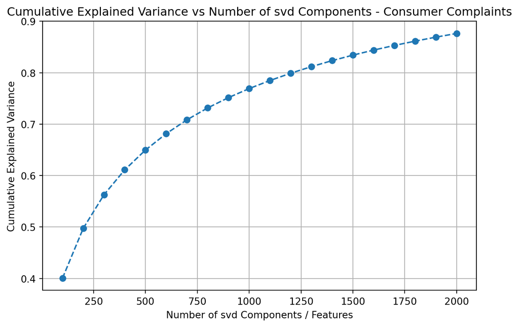

```python
# Section 2
component_range = range(100, 2001, 100)           # set range from 100 to 2000, gap = 100
explained_variances = []

for n in component_range:
    svd = TruncatedSVD(n_components=n, random_state=12345)
    svd.fit(tfidf_matrix)
    cumulative_variance = np.sum(svd.explained_variance_ratio_)
    explained_variances.append(cumulative_variance)
    print(f"{n} unique terms/features: {cumulative_variance:.2%} variance is explained") # 2 d.p. in printing cumulative_variance

# line graph
plt.figure(figsize=(8, 5))
plt.plot(component_range, explained_variances, marker='o', linestyle='--')
plt.xlabel('Number of svd Components / Features')
plt.ylabel('Cumulative Explained Variance')
plt.title('Cumulative Explained Variance vs Number of svd Components - Consumer Complaints')
plt.grid(True)
plt.show()
```

##### Section 3 Explain: In this section, I implement the dimensionality reduction (using TruncatedSVD) to the original TF-IDF matrix. In Section 2, I have proved that n = 1200 can capture 79.89% of variation (my target), which is a good balance between efficiency and information retention. To be more specific, reducing the number of unique terms (features) from 10783 to 1200 has two 2 advantages: 1, It largely improves computational efficiency 2, It filters out noises and many less important details.

```python
# Section 3
n = 1200
svd = TruncatedSVD(n_components = n, random_state=12345)
tfidf_reduced = svd.fit_transform(tfidf_matrix)
```

### Part 1-4: Compute the Cosine Similarity Matrix for the TF-IDF vectors

##### Explain: This part is not complicated. The first line computes the cosine similarity between every pair of documents in the TF-IDF matrix, which quantifies how similar each customer complaint is to every other customer complaint.

```python
cosine_similarity_matrix = cosine_similarity(tfidf_reduced)

# this is optional, but I print the top left 5x5 matrix to test if matrix is "normal": The diagonal statistics should all be 1.
print(cosine_similarity_matrix[:5, :5])
```

```
[[1.         0.0931442  0.00818144 0.05358177 0.02681538]
 [0.0931442  1.         0.11829206 0.05650913 0.06179933]
 [0.00818144 0.11829206 1.         0.07786034 0.03819421]
 [0.05358177 0.05650913 0.07786034 1.         0.04682925]
 [0.02681538 0.06179933 0.03819421 0.04682925 1.        ]]
```

### Part 1-5: Grouping by different financial products

##### Explain: I use a for loop to iterate when calculating the cosine similarity scores for each product category. Simply speaking, I group sampled_cc_df based on Product, and for each product group, I extract the relevant submatrix for each product group from the precomputed matrix (in Part 1-4), and then calculate the average cosine similarity among those documents.

```python
grouped = sampled_cc_df.groupby('Product')
group_similarity_stats = []


for product, group in grouped:
    indices = group.index.values

    submatrix = cosine_similarity_matrix[np.ix_(indices, indices)]         # extract the submatrix of similarities for this product group
    total_similarity = submatrix.sum() - len(indices)                      # remove self-similarity values (diagonals are 1's)

    count = len(indices)**2 - len(indices)                                 # total number of off-diagonal(unique) pairs = n^2 - n
    avg_similarity = total_similarity / count
    group_similarity_stats.append((product, len(indices), avg_similarity))


group_similarity_df = pd.DataFrame(group_similarity_stats, columns=['Product', 'Count', 'AvgCosineSimilarity']) # define column names
group_similarity_df = group_similarity_df.sort_values(by='AvgCosineSimilarity', ascending=False)                # decending order

print("Group similarity statistics of Customer Complaints across different Financial Products:")
print(group_similarity_df)
```

```
Group similarity statistics of Customer Complaints across different Financial Products:
                                              Product  Count  \
11                                    Money transfers     30
17                                       Prepaid card    142
9                           Debt or credit management     47
10  Money transfer, virtual currency, or money ser...   1759
7   Credit reporting, credit repair services, or o...  15803
18                                       Student loan    973
12                                           Mortgage   2554
0                             Bank account or service    280
14                                        Payday loan     23
6   Credit reporting or other personal consumer re...  17004
19                              Vehicle loan or lease    723
15          Payday loan, title loan, or personal loan    345
16  Payday loan, title loan, personal loan, or adv...    152
```

[output cut: 29 more lines]

### Part 1-6: Bar Chart - Grouped by Products

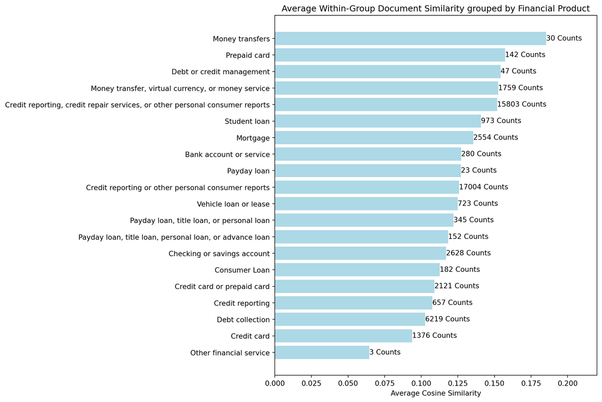

```python
plt.figure(figsize=(12, 8))
bars = plt.barh(group_similarity_df['Product'], group_similarity_df['AvgCosineSimilarity'], color='lightblue')
plt.xlabel('Average Cosine Similarity')
plt.title('Average Within-Group Document Similarity grouped by Financial Product')
plt.gca().invert_yaxis()
plt.xlim(0, 0.22)

# include count numbers
for bar, count in zip(bars, group_similarity_df['Count']):
    plt.text(bar.get_width(), bar.get_y() + bar.get_height()/2, f'{count} Counts', va='center')

plt.tight_layout()
plt.show()
```

#### Part 1 - Similarity: Overall Comment

##### This similarity analysis leverages cosine similarity computed from TF‑IDF vectors that have been reduced via SVD to capture approximately 80% of the variance, ensuring that we focus on the most relevant features while minimizing noise. By computing the cosine similarity for the reduced vectors, we obtain a measure of how similarly each pair of consumer complaint narratives is expressed, regardless of text length or absolute term frequency. This approach emphasizes the direction of the complaint vectors—the relative importance of words—as cosine similarity focuses on the angle between vectors rather than their magnitude. This is particularly useful in text data, where consumers often use a limited and consistent vocabulary to express recurring issues.

##### When I group the documents by financial product, the average cosine similarity scores reveal distinct communication patterns that can serve as indicators of underlying issues. For example, product categories such as **“Money transfers,” “Prepaid card,” and “Debit/Credit management”** consistently exhibit **high cosine similarity values**. This indicates that within these groups, **consumers tend to use a very similar vocabulary and phrasing** when describing their experiences. Such high uniformity in language suggests that the problems encountered by these consumers may be driven by **systematic issues—potentially recurring technical failures**, standardized service procedures, or policy shortcomings that force a similar pattern of complaints. In a scenario where the root cause is consistent across cases, one would expect the narratives to reflect near-identical structures and terminology, which is exactly what the high cosine similarity scores imply. The variation in language here suggests that the issues might be more systematic, **requiring service providers conduct thorough investigations into their operational and technical processes.**

##### In contrast, product categories like **“Credit reporting,” “Debt collection,” and “Other financial service”** show significantly **lower average similarity scores**. This lower consistency in language indicates that the consumer experiences and the **issues they face in these areas vary widely**. When complaints are more individualized and nuanced, customers tend to use a broader range of descriptive language to articulate their problems. This diversity can be due to a multitude of factors—ranging from personalized issues specific to an individual’s situation, to complex scenarios that do not lend themselves to a standardized description. As a result, the cosine similarity scores drop because the relative direction of the TF‑IDF vectors diverges more across documents, reflecting a higher variability in the narratives. The variation in language here suggests that the issues might be more individualized or complex, **requiring more nuanced and personalized solutions from service providers.**

##### However, It is important to consider that the robustness of these conclusions depends heavily on sample sizes. While a 2% sample of a multi-million-row dataset still yields a sizable and generally representative corpus, some product categories—such as “Payday loan” with only 23 entries, “Debit/Credit management” with 47 entries, or “Other financial service” with merely 3 entries—provide **less reliable average similarity estimates due to their limited representation**. This imbalance means that while the high similarity scores in well-represented categories are likely robust, conclusions drawn from sparsely populated categories should be interpreted with caution. Future work could benefit from **targeted resampling or oversampling in these underrepresented groups** to achieve more reliable estimates.

##### Overall, this analysis provides a data-driven perspective on how consumer complaints differ across financial products. By highlighting consistent language patterns in some products and diversity in others, the findings offer actionable insights. **Companies with high internal similarity may need to investigate standardized service failures, while those with diverse complaint narratives might consider more tailored solutions**. This nuanced understanding of complaint uniformity underscores the potential for improving product-specific customer support strategies and addressing systemic issues within these financial domains.

### Part 2 - Unsupervised Learning: EU Debates Dataset

#### **Research Question: How does the focus of EU debates IN ENGLISH change over time, and what trends in political discourse can be observed by analyzing the evolution of clusters in debate speeches?**

#### Part 2-1: Cleaning

##### In Part 2, I will use eu_df as my raw data, to investigate my research question. But the first step is still doing cleaning work to the raw data. **Taking Samples (25% of raw data with SRS) and Text Standardization** are similar procedures I have done In Part 1 before, however, due to the special feature of this dataset, I will need to conduct a **English Filter Process.** because my research question only focus on EU debates in English.

##### Across all debates, only part of them are done in English. I could filter by only including the columns where language = en, which is one column already there in the raw data. However, some English words will still be used even if the whole text is classified as other languages. To keep them, I introduced **langdetect module to detect English** words to make sure all English representations are captured.

```python
# Define - langdetect: English filter
def is_english(text):
    try:
        return detect(text) == 'en'
    except:
        return False

# 25% sample with SRS
eu_df_sample = eu_df.sample(frac=0.25, random_state=12345).reset_index(drop=True)

# Apply - langdetect: English filter
eu_df_sample = eu_df_sample[eu_df_sample['text'].apply(is_english)]
eu_df_sample = eu_df_sample.reset_index(drop=True)


# Text standardization
def clean_text(text):
    text = str(text).lower().strip()             # Convert to string, lowercase, and trim whitespace
    text = re.sub(r'\d+', '', text)               # Remove numbers
    text = re.sub(r'[^\w\s]', '', text)           # Remove punctuation
    return text

# Apply text standardization
eu_df_sample['clean_text'] = eu_df_sample['text'].apply(clean_text)


# TF-IDF Transformation
tfidf_vectorizer = TfidfVectorizer(stop_words='english', max_df=0.9, min_df=5)
tfidf_matrix = tfidf_vectorizer.fit_transform(eu_df_sample['clean_text'])
print("TF-IDF matrix shape:", tfidf_matrix.shape)
```

```
TF-IDF matrix shape: (12645, 12339)
```

#### Part 2-2: dimensionality reduction

```
1500 unique terms/features: 66.26% variance is explained
1600 unique terms/features: 67.95% variance is explained
1700 unique terms/features: 69.53% variance is explained
1800 unique terms/features: 71.01% variance is explained
1900 unique terms/features: 72.42% variance is explained
2000 unique terms/features: 73.74% variance is explained
2100 unique terms/features: 74.99% variance is explained
2200 unique terms/features: 76.18% variance is explained
2300 unique terms/features: 77.30% variance is explained
2400 unique terms/features: 78.37% variance is explained
2500 unique terms/features: 79.38% variance is explained
2600 unique terms/features: 80.35% variance is explained
2700 unique terms/features: 81.27% variance is explained
2800 unique terms/features: 82.14% variance is explained
2900 unique terms/features: 82.97% variance is explained
3000 unique terms/features: 83.76% variance is explained
```

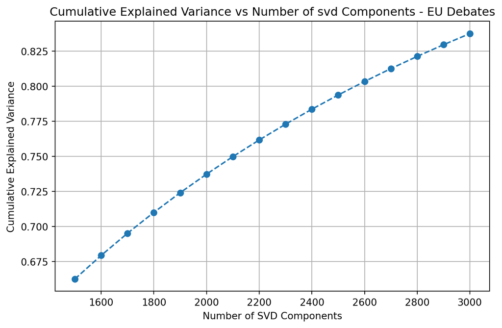

```python
component_range = range(1500, 3001, 100)  # Testing from 1500 to 3000 with gap = 100
explained_variances = []

for n in component_range:
    svd_temp = TruncatedSVD(n_components=n, random_state=12345)
    svd_temp.fit(tfidf_matrix)
    cumulative_variance = np.sum(svd_temp.explained_variance_ratio_)
    explained_variances.append(cumulative_variance)
    print(f"{n} unique terms/features: {cumulative_variance:.2%} variance is explained")

# line graph
plt.figure(figsize=(8, 5))
plt.plot(component_range, explained_variances, marker='o', linestyle='--')
plt.xlabel('Number of SVD Components')
plt.ylabel('Cumulative Explained Variance')
plt.title('Cumulative Explained Variance vs Number of svd Components - EU Debates')
plt.grid(True)
plt.show()
```

##### Based on the plot, set n_components = 2600 to reach roughly 80% variation coverage

```python
n_components = 2600
svd = TruncatedSVD(n_components=n_components, random_state=12345)
tfidf_reduced = svd.fit_transform(tfidf_matrix)
print("Reduced TF-IDF matrix shape:", tfidf_reduced.shape)
```

```
Reduced TF-IDF matrix shape: (12645, 2600)
```